# Data Cleaning Procedures

Data Analysis Report

2026-08-31

# Introduction

Data cleaning is a crucial step in the data analysis pipeline. It ensures that the dataset is accurate, consistent, and reliable for further analysis or modeling. In this document, we will demonstrate three primary data cleaning procedures using the built-in R datasets `iris` and `mtcars`:

1. **Handling Missing Values**
2. **Removing Duplicates**
3. **Outlier Detection**

Since `iris` and `mtcars` are inherently clean datasets, we will artificially introduce missing values and duplicates to demonstrate the cleaning techniques effectively.

# 1. Handling Missing Values

Missing values can skew analysis and cause errors in statistical modeling. Common strategies include removing rows with missing data or imputing them with mean, median, or mode.

## Demonstration on `iris`

First, we will artificially introduce `NA` (Not Available) values into the `iris` dataset.

```r
# Introduce missing values in Sepal.Length and Petal.Width
iris_missing <- iris
iris_missing$Sepal.Length[c(5, 15, 30, 50, 34, 70, 130, 80, 144)] <- NA
iris_missing$Petal.Width[c(10, 40, 53, 81, 04, 52, 132)] <- NA

# Check for missing values
colSums(is.na(iris_missing))
```

```
## Sepal.Length  Sepal.Width Petal.Length  Petal.Width      Species
##            9            0            0            7            0
```

**Visualizing Missing Data**

It is often helpful to visualize where missing data occurs. We can create a robust visualization by converting the data to a `TRUE`/`FALSE` matrix indicating missingness, and then plotting it.

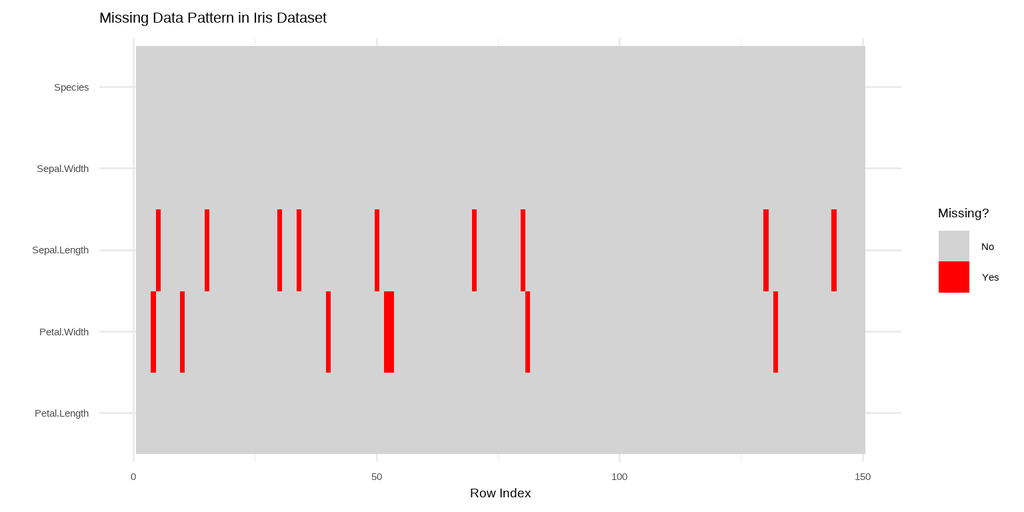

```r
# 1. Convert the dataset to a TRUE/FALSE matrix for missing values
missing_matrix <- as.data.frame(is.na(iris_missing))
missing_matrix$row_num <- 1:nrow(missing_matrix)

# 2. Pivot to long format for ggplot
missing_plot_df <- missing_matrix %>%
  pivot_longer(-row_num, names_to = "Variable", values_to = "Is_Missing")

# 3. Plot the missing data pattern
ggplot(missing_plot_df, aes(x = row_num, y = Variable, fill = Is_Missing)) +
  geom_raster() +
  scale_fill_manual(values = c("TRUE" = "red", "FALSE" = "lightgray"), name = "Missing?", labels = c("No", "Yes")) +
  labs(title = "Missing Data Pattern in Iris Dataset", x = "Row Index", y = "") +
  theme_minimal(base_size = 14)
```

**Strategy: Imputing NAs with the Mean**

We will impute the missing values with the column mean and visualize the distribution before and after to show the impact.

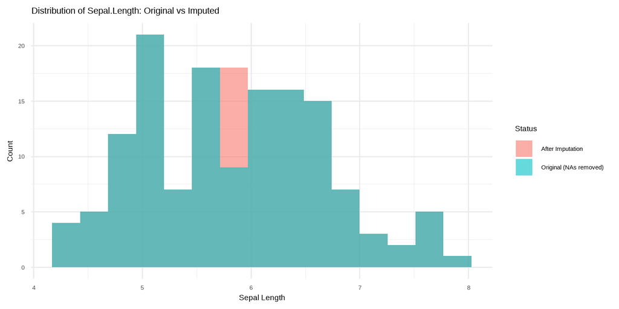

```r
iris_imputed <- iris_missing %>%
  mutate(
    Sepal.Length = ifelse(is.na(Sepal.Length), mean(Sepal.Length, na.rm = TRUE), Sepal.Length),
    Petal.Width = ifelse(is.na(Petal.Width), mean(Petal.Width, na.rm = TRUE), Petal.Width)
  )

# Plotting distribution before and after imputation for Sepal.Length
df_vis <- data.frame(
  Value = c(iris_missing$Sepal.Length[!is.na(iris_missing$Sepal.Length)], iris_imputed$Sepal.Length),
  Status = c(
    rep("Original (NAs removed)", length(na.omit(iris_missing$Sepal.Length))),
    rep("After Imputation", nrow(iris_imputed))
  )
)

ggplot(df_vis, aes(x = Value, fill = Status)) +
  geom_histogram(alpha = 0.6, position = "identity", bins = 15) +
  labs(title = "Distribution of Sepal.Length: Original vs Imputed", x = "Sepal Length", y = "Count") +
  theme_minimal(base_size = 14)
```

# 2. Removing Duplicates

Duplicate rows can lead to over-representation of certain observations, biasing the results. We need to identify and remove them.

## Demonstration on `iris`

We will duplicate a few rows from the `iris` dataset and then use the `distinct()` function from the `dplyr` package to remove them.

```r
# Create duplicates by binding the first 5 rows to the original dataset
iris_duplicated <- rbind(iris, iris[1:5, ])

cat("Rows with duplicates:", nrow(iris_duplicated), "\n")
```

```
## Rows with duplicates: 155
```

```r
# Remove duplicates
iris_unique <- distinct(iris_duplicated)

cat("Rows after removing duplicates:", nrow(iris_unique))
```

```
## Rows after removing duplicates: 149
```

**Visualizing Row Counts Before and After**

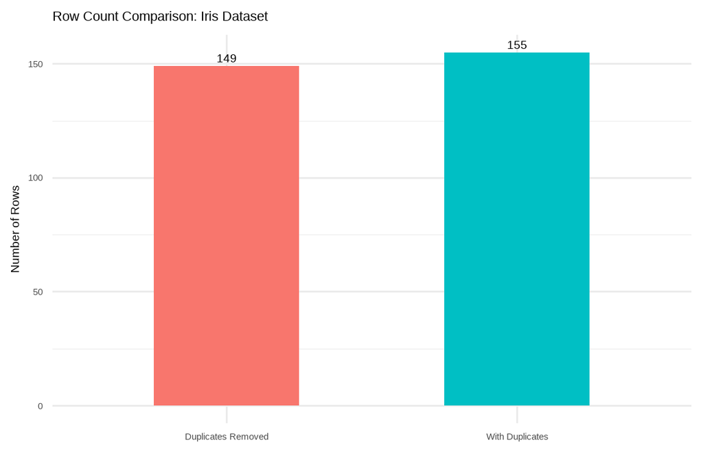

```r
df_counts <- data.frame(
  Status = c("With Duplicates", "Duplicates Removed"),
  Count = c(nrow(iris_duplicated), nrow(iris_unique))
)

ggplot(df_counts, aes(x = Status, y = Count, fill = Status)) +
  geom_col(width = 0.5) +
  geom_text(aes(label = Count), vjust = -0.5, size = 5) +
  labs(title = "Row Count Comparison: Iris Dataset", x = "", y = "Number of Rows") +
  theme_minimal(base_size = 14) +
  theme(legend.position = "none")
```

# 3. Outlier Detection

Outliers are data points that differ significantly from other observations. They can be caused by measurement errors or natural variability. A common method for detecting outliers is the **Interquartile Range (IQR)** method. Data points falling below $Q1 - 1.5 \times IQR$ or above $Q3 + 1.5 \times IQR$ are considered outliers.

## Demonstration on `iris`

Let’s detect outliers in the `Sepal.Width` column of the `iris` dataset using boxplot statistics and visualize them on a scatter plot.

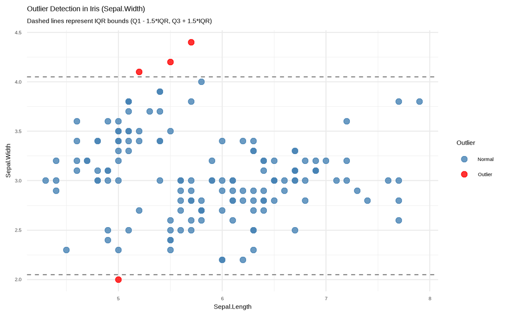

```r
# Calculate Q1, Q3, and IQR
Q1 <- quantile(iris$Sepal.Width, 0.25)
Q3 <- quantile(iris$Sepal.Width, 0.75)
IQR_val <- Q3 - Q1

# Define upper and lower bounds
lower_bound <- Q1 - 1.5 * IQR_val
upper_bound <- Q3 + 1.5 * IQR_val

# Identify outliers and add a label
iris_outlier_vis <- iris %>%
  mutate(Outlier = ifelse(Sepal.Width < lower_bound | Sepal.Width > upper_bound, "Outlier", "Normal"))

# Visualizing outliers with a scatter plot (Sepal.Width vs Sepal.Length)
ggplot(iris_outlier_vis, aes(x = Sepal.Length, y = Sepal.Width, color = Outlier)) +
  geom_point(size = 3, alpha = 0.8) +
  scale_color_manual(values = c("Normal" = "steelblue", "Outlier" = "red")) +
  geom_hline(yintercept = c(lower_bound, upper_bound), linetype = "dashed", color = "gray50") +
  labs(
    title = "Outlier Detection in Iris (Sepal.Width)",
    subtitle = "Dashed lines represent IQR bounds (Q1 - 1.5*IQR, Q3 + 1.5*IQR)"
  ) +
  theme_minimal(base_size = 14)
```

## Demonstration on `mtcars`

We will apply the same IQR method to detect outliers in the `hp` (Horsepower) column of the `mtcars` dataset and visualize them using a bar chart.

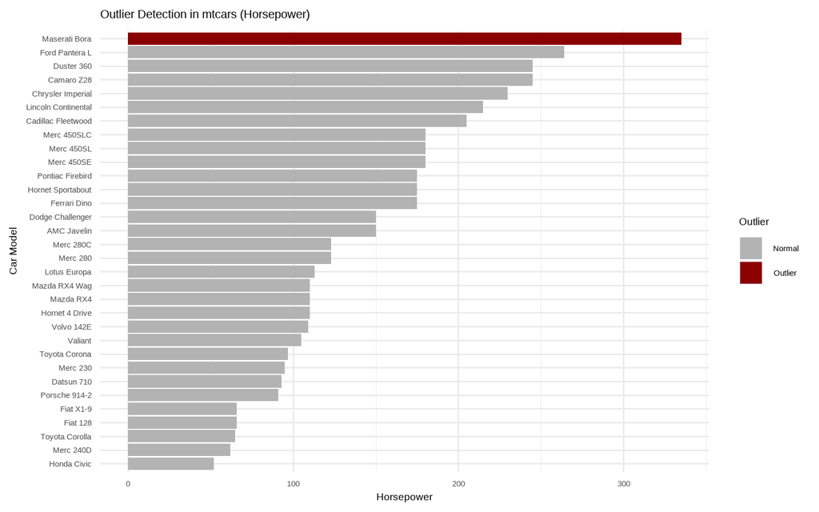

```r
# Calculate Q1, Q3, and IQR for hp
Q1_hp <- quantile(mtcars$hp, 0.25)
Q3_hp <- quantile(mtcars$hp, 0.75)
IQR_hp <- Q3_hp - Q1_hp

# Define bounds
lower_bound_hp <- Q1_hp - 1.5 * IQR_hp
upper_bound_hp <- Q3_hp + 1.5 * IQR_hp

# Identify outliers
mtcars_outlier_vis <- mtcars %>%
  mutate(
    Car = rownames(mtcars),
    Outlier = ifelse(hp < lower_bound_hp | hp > upper_bound_hp, "Outlier", "Normal")
  )

# Visualizing outliers with a bar chart
ggplot(mtcars_outlier_vis, aes(x = reorder(Car, hp), y = hp, fill = Outlier)) +
  geom_col() +
  coord_flip() +
  scale_fill_manual(values = c("Normal" = "gray70", "Outlier" = "darkred")) +
  labs(
    title = "Outlier Detection in mtcars (Horsepower)",
    x = "Car Model",
    y = "Horsepower"
  ) +
  theme_minimal(base_size = 14)
```

# Conclusion

[output not shown]